# VirtualPop Simulation of individual lifespans and fertility careers

Frans Willekens

2025-04-11

\newpage

# Introduction

VirtualPop constructs a virtual populations from fertility and mortality rates for any country, calendar year (period data) and birth cohort (cohort data) in the [Human Mortality Database (HMD)](https://www.mortality.org) and the [Human Fertility Database (HFD)](https://www.humanfertility.org). Cohort data refer to a birth cohort, e.g. individuals born in 1964. Period data refer to data collected in a given calendar year, e.g. 2021. VirtualPop constructs a virtual population in three steps. In the first step, VirtualPop retrieves data programmatically from the HMD and the HFD. The retrieved data are for a country specified by the user. The retrieved data have the necessary mortality and fertility rates, but they may have other data too. In the second step, the mortality and fertility rates are extracted for the selected birth cohort (cohort data) or calendar year (period data). In the third step, *lifespans* and *fertility histories* are generated for all individuals in the virtual population and their offspring. The population that results has multiple generations, which offers the opportunity to study kinship networks and other subject that involve multiple generations and that are not feasible in real populations due to lack of data or for other reasons.

During the simulation, VirtualPop generates a population register by recording the dates of the life events individuals experience, including marriage or union formation. The current version of VirtualPop uses a simple partner search model. VirtualPop includes two mortality scenarios: with and without mortality. If mortality is present, death is a competing risk.

The simulation relies on a multistate life history model [@willekens2014; @cook2018multistate]. The model describes the life course as a sequence of states and transitions between states. The transitions we observe are realizations of an underlying stochastic process. The multistate life history model captures the main features of the underlying process. The vignettes “Sampling Piecewise-Exponential Waiting Time Distributions” and “Simulation of life histories” describe the model and illustrate its application to real-world data. The vignettes can be read using the code provided in Section 3.1. The validity of the simulation and the virtual population is discussed in a separate paper, entitled “Validation of a virtual population”. A comparison of the virtual population with the reference population requires external data from registers and surveys. The pdf version of the paper is included in the doc file of the source package VirtualPop_1.1.0.tar.gz.

The virtual population can be produced in a single step produced using the function BuildViP(). The single step combines the three steps needed to generate a virtual population:

- Data retrieval: retrieval of data from the HMD and HFD.
- Rate computation: retrieval and computation of mortality and fertility rates.
- Building the virtual population.

The tutorial has 8 sections and two Appendices. The first section following the introduction lists the HMD and HFD data that are required and has a brief discussion of conditional fertility rates, more widely known as occurrence-exposure rates. Section 3 describes how to install VirtualPop, HMDHFDplus and other R packages VirtualPop relies on. Section 4 covers the production of a virtual population in a single step. The remaining sections cover each of the three steps in the production process. Downloading HMD and HFD data is covered in Section 5. Data may be downloaded manually or programmatically. The extraction of mortality and fertility rates and transforming the rates in the a format required by the multistate model is the subject of Section 6. Section 7 covers the simulation of individual lifespans and fertility histories with and without death as a competing risk. The tools discussed in Section 7 are used in Section 8 to produce a virtual population. It distinguishes between a virtual population generated from period data and a virtual population generated from cohort data. The Tutorial has two appendices. Appendix A is a description of the life histories data (dLH) object. Appendix B presents the code to export a virtual population from R to STATA and SPSS for data analysis.

# Data requirements

## List of data required

The HMD and HFD provide data for several countries. Countries are denoted by short codes of three letters (except for Great Britain and New Zealand). To get the list of countries and the code:

```r
countriesHMD <- HMDHFDplus::getHMDcountries()
countriesHFD <- HMDHFDplus::getHFDcountries()
# print (countries[,c(1,3)],n=nrow(countries))
```

The following data files are required for the simulation.

- Period data
  - Period life table for all years for which the data are available (1933 to 2021 in case of the United States).
    - Males: HMD data file \(mltper\_1x1\).
    - Females: HMD data file \(fltper\_1x1\).
  - Conditional fertility rates for all years for which the data are available: HFD data file \(mi\). The conditional fertility rates are also included in the period fertility tables ’$pft$.
- Cohort data
  - Cohort death rates for males and females for all birth cohorts for which the data are available. HMD data file \(cMx\_1x1\).
  - Conditional fertility rates for several birth cohorts. The rates are not available as a separate dataset, but are included in the cohort fertility tables (HFD data file \(cft\)).

## A note on conditional fertility rates

A distinction is made between fertility rates by birth order and fertility rates by parity. Birth order is a property of a child. Parity is a property of a woman. It is the number of children born to a woman (of a given age). Fertility rates by birth order relate the number of births to *all women* (of a given age). Fertility rates by parity relate the number of births to *women of a given parity*. The two types of fertility rates differ in the denominator. In the HFD, the first type is referred to as unconditional fertility rates and fertility rates by birth order, the second as conditional fertility rates and fertility rates by parity (HFD parity estimates) [@jasilioniene2015methods, p. 18].

Conditional fertility rates are *occurrence-exposure rates*. The latter is the term used in survival analysis, biostatistics and multistate demography (see e.g. @hoem1981multi, pp. 202ff; @aalen2008survival pp. 219ff.; @willekens2014). An occurrence-exposure rate relates the number of occurrences of an event in a given interval to the total duration of exposure to the risk of experiencing the event during that interval. In fertility analysis, the number of births of order j is related to the number of women at risk of giving birth to a j-th child. These are women with j-1 children ever born. Demographers use different terms to refer to occurrence-exposure rates, which is confusing. @preston2001demography[p. 3] and [@bongaarts2012demographic, p. 113] refer to occurrence-exposure rates as conditional fertility rates of the first kind. The HFD uses the term *conditional age- and order-specific fertility rates*, in short *conditional fertility rates* to denote occurrence-exposure rates [@jasilioniene2015methods; @jasilioniene2016data].

Fertility tables describe the process of childbearing in real or synthetic female cohorts, focusing on the age and parity dimension [@jasilioniene2016data, p. 3]. They are essentially multistate life tables. @schoen2006insights refers to the fertility table as parity status life table. For a discussion of the fertility table from a statistical perspective, see @chiang1982fertility and @li2020projecting.

# Install packages VirtualPop, HMDHFDplus and other packages used in this tutorial

## VirtualPop Version 1.1.0

To install \(VirtualPop\) and its dependencies from CRAN (Comprehensive R Archive Network), use

```r
install.packages ("VirtualPop")
```

To load and attach the package, use

```r
library (VirtualPop)
```

The package VirtualPop has three vignettes:

- *piecewise_exponential*: Sampling piecewise-exponential waiting time distribution
- *MultistateLH*: Simulation of life histories
- *Tutorial*: VirtualPop: Simulation of individual fertility careers from age-specific fertility and mortality rates

To list the vignettes, type

```r
utils::browseVignettes("VirtualPop")
```

To open and read the vignette containing this Tutorial, type

```r
utils::vignette (topic="Tutorial",package="VirtualPop")
```

To list the data included in the package:

```r
data(package="VirtualPop")
```

## HMDHFDplus Version 2.0.6

The data in the HMD and HFD are provided free of charge to registered users. At registration, basic contact information is obtained (i.e., name, e-mail address, affiliation, and title). To register, go to https://www.mortality.org and https://www.humanfertility.org . Upon acceptance of the agreement, you receive a password. The user name (e-mail address used at registration) and the password are required to download data. In this tutorial, it is assumed that you use the same e-mail address to register with the HMD and the HFD. If you registered before mid-2022, note that in 2022 HMD users were requested to re-register.

The HMDHFDplus package was developed by Tim Riffe and colleagues at the Max Planck Institute for Demographic Research in Rostock, Germany (@riffe2015hmdhfd). To install the package and check the version of the package installed, use:

```r
library (HMDHFDplus)
version <- packageVersion("HMDHFDplus") # 2.0.6
```

## Other packages used by VirtualPop

The package dependencies are installed automatically if you use install.packages(“VirtualPop”). VirtualPop depends on two packages included in R base (stats and utils) and on the following contributed packages: HMDHFDplus, foreign, lubridate, ggplot2, knitr, kableExtra, msm and Families. The package rmarkdown is used to produce the vignettes. These packages and the vignettes use additional packages, such as dplyr, tidyr, httr, rvest, readr, and survival. All packages are on CRAN. To obtain a list of the packages used, type:

```r
tools::package_dependencies(recursive = TRUE)$VirtualPop
```

Installed packages are stored in a folder. You may specify the folder or leave the selection to the operating system. The system keeps track of the location and knows where to find a package when needed. To find out where the packages are located, type .libPaths() in the console.

Once installed, the packages must be loaded, i.e. imported into the workspace. The traditional approach is to use the library() function. The function attaches a package to the search path and, when a function is called by name, R searches for packages in the order they are listed on the search path, e.g. the most recently loaded package is the first on the list. If two packages on the search path have a function with the same name, R takes the package first on the search path. It may not be the package you need. To prevent R from extracting the function from the wrong package, the R Core Team recommends to specify both the package and the function. The two names are separated by the double colon (::) operator. That practice, which replaces the library() function, is adopted in this paper.

To install the RStudio Integrated Development Environment (IDE) go to the Posit (formerly RStudio) website [here](https://posit.co/downloads/). If you are new to RStudio, you find an introduction for beginners [here](https://education.rstudio.com/learn/beginner/) and a tutorial [here](https://www.datacamp.com/tutorial/r-studio-tutorial).

# Generate a virtual population in a single step: the function BuildViP()

The single step combines the three steps. The three steps are:

- Retrieve the raw data from the HMD and HFD
- Prepare a dataset with mortality and fertility rates.
- Generate a virtual population and create the object \(dLH\). The object has information on all individuals in the multi-generational virtual population.

## For some countries, e.g. Bulgaria, HMDHFDplus produces an error when reading fertility data (HFD). The best response in that case is to download the HFD data manually and read the data locally.

```r
# Period data
a <- Sys.time()
dLH <- tryCatch(VirtualPop::BuildViP(user,pw_HMD,pw_HFD,
                             countrycode="USA",
                             refyear=2021,
                             ncohort=5000,
                             ngen=5),
                 error=function(cond) {message("Error reading HFD data. Download data and read data locally (see Tutorial Section 4.2).")})
b <- Sys.time()
b-a

# Period data; no mortality
dLHnm <- tryCatch(VirtualPop::BuildViP(user,pw_HMD,pw_HFD,
                             countrycode="USA",
                             refyear=2021,
                             ncohort=1000,
                             ngen=2,
                             mort=FALSE),
                                   error=function(cond) {message("Error reading HFD data. Download data and read data locally (see Tutorial Section 4.2).")})

# Cohort data
dLHc <- tryCatch(VirtualPop::BuildViP (user,pw_HMD,pw_HFD,
                          countrycode="USA",
                          cohort=1964,
                          ncohort=1000,
                          ngen=5,
                          mort=TRUE),
                                  error=function(cond) {message("Error reading HFD data. Download data and read data locally (see Tutorial Section 4.2).")})

# Specify pathSave, the folder to save dLH.
pathSave <- "Name of folder to save dLH"
pathSave <- "/Users/frans/VirtualPop_data/"
fileSave <-paste0("dLH_",attr(dLH,"country"),attr(dLH,"refyear"),"_",
                  max(dLH$gen)-1,"_",length(dLH$ID[dLH$gen==1]),".RData")
# or paste0("dLHc_".....   or  paste0("dLHnm_".....
save(dLH,file=paste0(pathSave,fileSave))
```

# Download HMD and HFD data

To download the data, you may consider two options. The first is to download the data manually. The second is to download the data programmatically using the package HMDHFDplus. Two types of data are distinguished: period data and cohort data. Period data pertain to calendar years. Cohort data pertain to birth cohorts.

## Download data manually

Before downloading data, you are requested to provide your email address and password.

a. *Period data*

The URLs of the period data files for the United State are:

- https://www.mortality.org/File/GetDocument/hmd.v6/USA/STATS/fltper_1x1.txt
- https://www.mortality.org/File/GetDocument/hmd.v6/USA/STATS/mltper_1x1.txt

and

- https://www.humanfertility.org/File/GetDocument/Files/USA/20230328/USAmi.txt

For the fertility data, select “Conditional age-specific fertility rates”.

Save the data in a folder and record the path, e.g.

```r
path <- "/users/frans/VirtualPop_data/"
```

The function read.table() of the utils package, which is part of base R, imports the data into the R workspace

```r
dm <- utils::read.table(paste0(path,"mltper_1x1.txt"),skip=2,header=TRUE)
df <- utils::read.table(paste0(path,"fltper_1x1.txt"),skip=2,header=TRUE)
fert_rates <- utils::read.table(paste0(path,"USAmi.txt"),skip=2,header=TRUE)
```

where path is the location of the data. The code removes the first two lines in \(mltper\_1x1.txt\), \(fltper\_1x1.txt\) and \(USAmi.txt\).

The objects dm and df include the period life tables for every year between 1933 and 2021. The object fert_rates includes the conditional fertility rates for every year from 1963 to 2021.

The ages are character objects. In the HMD, the ages range from 0 to 110+ and in the HFD from 12- and 55+. The ages are character variables. They should be converted to numeric values manually.

To save the raw data in a single object, called data_raw, use:

```r
countrycode <- "USA"
data_raw <- list (country=countrycode,LTf=df,LTm=dm,fert_rates=fert_rates)
attr(data_raw,"country") <- countrycode
data_raw <- data_raw
```

An object attribute is added to identify the country.

To save the data as an R data file under a name that refers to the country, specify the path to the location (folder):

```r
path1 <- "Define the path to the folder to save the data locally"
save (data_raw,file=paste(path1,"data_raw",countrycode,".RData",sep=""))
```

If the desired location is current working directory, path is empty (\(""\)).

If you are using Rstudio integrated development environment (IDE) and defined a project, the file is saved in the *project directory*. The project directory points to the folder where the \(.Rproj\) file is saved, which in Rstudio is called *root folder*. It differs from the *current working directory* displayed by the RStudio IDE within the title region of the Console pane. The function \(getwd()\) called from the Rstudio console retrieves the directory listed as the title of the Console pane. The reason for the difference is that R defines an *absolute* file path (set by \(setwd()\)) and Rstudio defines a *relative* file path. The relative path is not affected by a migration of \(.Rproj\) to another location, but the absolute path is.

b. *Cohort data*

The URLs of the files for the United States are:

- https://www.mortality.org/File/GetDocument/hmd.v6/USA/STATS/cMx_1x1.txt
- https://www.humanfertility.org/File/GetDocument/Files/USA/20230328/USAcft.txt

The data set \(cMx\_1x1\) contains the cohort mortality rates for males and females for the years 1852 to 1991 and \(cft\) has the cohort fertility tables for the birth cohorts 1918 to 1996. The following code reads the data locally.

```r
path <- "Define the path to the data on your computer"
cmortrates <- utils::read.table(paste0(path,"cMx_1x1.txt"),skip=2,header=TRUE)
cfertTables <- utils::read.table(paste0(path,"cft.txt"),skip=2,header=TRUE)
```

## Download data programmatically

Registration with the HMD and HFD is required before downloading data. At registration, you provide a user name (-mail address) and receive a password. They should be stored in the following objects:

```r
user <- "your email address"
pw_HMD <- "password for HMD" ## (password for new (2022) HMD website)
pw_HFD <- "password for HFD"
```

## For some countries, e.g. Bulgaria, HMDHFDplus produces an error when reading fertility data (HFD). The best response in that case is to download the HFD data manually and read the data locally. The issue is expected to be resolved soon.

a. *Period data*

To download data of the United States, use:

```r
data_raw <- VirtualPop::GetData (country="USA",user,pw_HMD,pw_HFD)
```

The function GetData() uses the functions readHMDweb() and readHFDweb() of the package HMDHFDplus. The code is:

```r
df <- HMDHFDplus::readHMDweb(CNTRY=countrycode,item="fltper_1x1",username=user,
         password=pw_HMD,fixup=TRUE)
dm <- HMDHFDplus::readHMDweb(CNTRY=countrycode,item="mltper_1x1",username=user,
        password=pw_HMD,fixup=TRUE)
fert_rates <- HMDHFDplus::readHFDweb(CNTRY=countrycode,item="mi",username=user,
        password=pw_HFD,fixup=TRUE)
```

- country: country
- LTf: period life tables for females (\(fltper\_1x1\)) for all years for which the data are available (1933 to 2021 in case of the United States).
- LTm: Life table for males (\(mltper\_1x1\)).
- fert_rates: conditional fertility rates (\(mi.txt\)) for all years for which the data are available (1963 to 2021 in case of the United States).

The ages are character objects. In the HMD, the ages range from 0 to 110+ and in the HFD from 12- and 55+. HMDHFDplus, used by GetData(), has an option to convert the ages to numeric values (fixup=TRUE), which should be used. If the connection with the server that stores the HMD and HFD cannot be made or data are not available for the selected country, the error message “HTTP error 404” is returned.

b. *Cohort data*

Let’s retrieve the cohort mortality rates and the cohort fertility tables rates for the USA.

```r
countrycode <- "USA"
cmrates <- HMDHFDplus::readHMDweb(CNTRY=countrycode,item="cMx_1x1",
        username=user, password=pw_HMD,fixup=TRUE)
cfertTables <- HMDHFDplus::readHFDweb(CNTRY=countrycode,item="cft",
        username=user, password=pw_HFD,fixup=TRUE)
# List cohorts for which data are downloaded
cohortsHMD <- unique(cmrates$Year)
cohortsHFD <- unique(cfertTables$Cohort)
```

# Mortality and fertility rates

## Period mortality and fertility rates

The function GetRates() extract the period rates for a selected reference year from the object \(data\_raw\). In this tutorial, the reference year is 2021 and the country is USA.

```r
refyear <- 2021
```

```r
rates <- VirtualPop::GetRates(data=data_raw,refyear=refyear)
```

The following code saves the rates:

```r
save (rates,file=paste(path,"rates",countrycode,"_",refyear,".RData",sep=""))
```

The last code chunks are not executed because the chunks in the previous section were not executed. Instead, the rates are taken from the VirtualPop package, which includes the period rates as a data object. To load the rates, use

```r
utils::data(rates,package="VirtualPop")
```

where \(rates\) is the data object. It is a list object with three components:

- ASDR: The age-specific death rates by sex.
- ASFR: The age-specific fertility rates by birth order.
- ratesM: The age-specific fertility rates by birth order in the format required by the multistate model used to simulate the fertility histories.

The list object has two attributes; country (USA) and calendar year (2021).

The third component contains the transition rate matrix by age ([@willekens2014; the VirtualPop package vignette “Simulation of life histories”]. The code to display the vignette is:

```r
utils::vignette (topic="Multistate",package="VirtualPop")
```

## Cohort mortality and fertility rates

The function GetRatesC() retrieves the cohort mortality rates (cMx_1x1) directly from the HMD and extract the cohort fertility tables (\(cft\) in HFD) directly from the HFD for a given country and a selected birth cohort. It subsequently extracts the conditional fertility rates from the cohort life table. In this tutorial, the country is USA and the birth cohort 1964. The birth cohort reached the end of the reproductive period (age 55) in 2019. Most cohort members are still alive at age 55. The mortality experience of the cohort is incomplete. To complete the mortality experience of the cohort, period rates of the most recent calendar year (2021) are used. The function GetRatesC() returns the augmented cohort death rates (ASMR) and the conditional fertility rates (ASFR). The function also produces the transition rates for the multistate modelling of fertility histories.

```r
ratesC  <- VirtualPop::GetRatesC(country="USA",user,pw_HMD,pw_HFD,refcohort=1964)
save (rates,file=paste(path,"ratesC",countrycode,"_",refyear,".RData",sep=""))
```

The rates for the USA birth cohort 1964 are distributed with the VirtualPop package and may be loaded using:

```r
utils::data(ratesC,package="VirtualPop")
```

The object \(ratesC\) has five attributes:

- Country: country (USA)
- type: Type of data (cohort)
- cohort: Birth cohort (1964)
- refyear: calendar year data used to complete the cohort experience. It is the most recent year with period data, in this case 2021. The most recent year with mortality data is selected automatically by GetRatesC().
- start_pASDR: lowest age with missing age-specific death rates for the selected cohort. Starting at that age, the missing cohort rates are replaced by period rates of the most recent year (2021). The age is determined by GetRatesC().

# Simulate lifespans and fertility histories

The objects rates and ratesC are used to simulate ages at death and fertility histories of members of a virtual population (synthetic cohort). The synthetic cohort consists of 1,000 individuals. The sex ratio at birth is 1.05 males per female. To determine the sex of a cohort member a random number is drawn from a binomial distribution (0 is male and 1 is female). The year of birth of the hypothetical cohort is assumed to be equal to the reference year (2021). The precise dates of birth (decimal dates) of cohort members are obtained by adding to the year random numbers drawn from the standard uniform distribution. In this section lifespans are generated from period mortality rates by age and sex of a the USA in 2021.

## Lifespans

The methodology is described in the VirtualPop package vignette “Sampling piecewise-exponential waiting time distributions” [see also @willekens2014]. The vignette is retrieved by calling utils::vignette():

```r
utils::vignette (topic="Piecewise_exponential",package="VirtualPop")
```

The code to produce individual ages at death is:

```r
ncohort <- 1000
refyear <- attr(rates,"year")
sex <- rbinom(ncohort,1,prob=1/2.05)
sex <- factor (sex,levels=c(0,1),labels=c("Male","Female"),ordered=TRUE)
## Decimal date of birth
bdated <- refyear+runif(ncohort)
dLS <- data.frame(ID=1:ncohort,sex=sex,bdated=bdated)
dLS <- VirtualPop::Lifespan (data=dLS,ASDR=rates$ASDR)
```

\(dLS\) is a dataframe with one row for each member of the synthetic cohort and one column for each variable. In the absence of mortality, a maximum age (120) is allocated to all individuals. The function call is

```r
dLSnm <- VirtualPop::Lifespan (data=dLS,ASDR=rates$ASDR,mort=FALSE)
```

The mean and the variability of age at death are computed in the next code chunk. The variability is measured by the standard deviation. The standard deviation is a measures of variability of the age at death [@raalte2012lifespanvariation].

```r
a <- stats::aggregate(dLS$x_D,by=list(dLS$sex),mean)
a2 <- stats::aggregate(dLS$x_D,by=list(dLS$sex),median)
## Lifespan variation: standard deviation of age at death
b <- stats::aggregate(dLS$x_D,by=list(dLS$sex),sd)
z <- t(data.frame(mean=round(a$x,2),median=round(a2$x,2),sd=round(b$x,2)))
colnames(z) <- a[,1]
out <- knitr::kable(z,format = "simple",
             caption = "Mean and variability of ages at death, by sex")
kableExtra::kable_styling(out,latex_options="HOLD_position")
```

Table: Mean and variability of ages at death, by sex

```
       Male   Female
```

mean 73.37 80.46 median 76.57 83.79 sd 17.08 15.41

Figure 1 shows the ages at death of members of the virtual population.

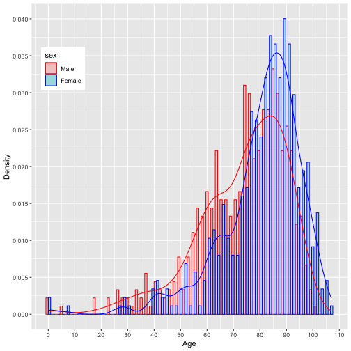

Simulated ages at death, USA, 2021

```r
dLS$x_D[dLS$x_D>110] <- 110
binwidth <- (max(dLS$x_D,na.rm=TRUE)-min(dLS$x_D,na.rm=TRUE))/60
require (ggplot2)
p <- ggplot() +
  geom_histogram(data=dLS,aes(x=x_D,color=sex,fill=sex,y=after_stat(density)),
                 alpha=0.5,position="dodge",binwidth=binwidth) +
  geom_density(data =dLS,aes(x_D, colour = sex), alpha = .2)
p <- p + scale_color_manual(values=c("red", "blue"))
p <- p + scale_fill_hue(c=45, l=80)
xmin <- 0
xmax <- 110
p <- p + xlab("Age")+ylab("Density")
p <- p +  scale_x_continuous(breaks=seq(xmin,xmax,by=10))
p <- p + scale_y_continuous (breaks=seq(0,0.04,by=0.005))
p <- p + theme(legend.position = "inside",legend.position.inside = c(0.1, 0.8))
p
```

## Fertility histories with and without death as a competing risk

The function Sim_bio() simulates an individual fertility history from age-specific fertility rates starting at birth and the end of the fertility career. Sim_bio() uses the three-dimensional array rates$ratesM, which contains the fertility rates by parity in the format used in multistate demographic and statistical modelling [@willekens2014, p. 31]. The end of the fertility career is the end of the reproductive period, the age of a competing event that interrupts the fertility career and precludes a new childbirth (e.g. death), or the age at which simulation is terminated (censoring), whichever comes first. The highest age is provided by the user or drawn from a waiting time distribution. The latter is implemented in the Lifespan() function.

In this section, we first simulate the fertility history of one individual. The simulation of fertility histories of multiple individuals is considered next. The rates used are period rates. Consider individual with ID equal to 1 and assume that the individual is born on 9th May 1999, which is 1999.351 in decimal year^[The lubridate package is used to convert a calendar date to a decimal year: lubridate::decimal_date(lubridate::ymd(“1999-05-09”))]. The simulation starts at age 0 and ends at age 85. If the age at death is higher than the end of the reproductive period (age 55), the sequence of births is not affected by the age at death. The individual starts in state par0 (parity 0).

```r
set.seed(32)
popsim <- data.frame(ID=1,born=1999.351,start=0,end=85,st_start="par0")
ch <- VirtualPop::Sim_bio (datsim=popsim,ratesM=rates$ratesM)
paste0("Simulation of single fertility career, ",countrycode,", ",refyear)
[1] "Simulation of single fertility career, USA, 2021"
ch
$age_startSim
[1] 0

$age_endSim
[1] 56

$nstates
[1] 4

$states
[1] 1 2 3 4

$path
[1] "par0par1par2par3"

$ages_trans
[1] 17.45187 22.28471 38.72305
```

The individual has a first child at age 17.45, a second at 22.28 and a third at 38.72.

In the presence of mortality, the highest age is the end of the reproductive period (age 56) or the age at death, whichever comes first.Let’s use Lifespan() to draw a random age at death from the age-at-death distribution of the USA population in 2021.

```r
ncohort <- 1
sex <- rbinom(ncohort,1,prob=1/2.05)
sex <- factor (sex,levels=c(0,1),labels=c("Male","Female"),ordered=TRUE)
dLS <- data.frame(ID=1,sex=sex,bdated=1999.351)
dLS <- VirtualPop::Lifespan(data=dLS,ASDR=rates$ASDR)
popsim <- data.frame(ID=1,born=1999.351,start=0,end=dLS$x_D,st_start="par0")
set.seed(32)
ch <- VirtualPop::Sim_bio (datsim=popsim,ratesM=rates$ratesM)
paste0("Simulation of single fertility career, ",countrycode,", ",refyear)
[1] "Simulation of single fertility career, USA, 2021"
ch
$age_startSim
[1] 0

$age_endSim
[1] 56

$nstates
[1] 4

$states
[1] 1 2 3 4

$path
[1] "par0par1par2par3"

$ages_trans
[1] 17.45187 22.28471 38.72305
```

Let’s now simulate the fertility histories of three women and store the result in a list vector of length three.

```r
n <- 3
bdated <- c(1999.350,2010.650,2015.340)
popsim <-data.frame(ID=1:3,born=bdated,start=rep(0,n),end=rep(85,n),
  st_start=c("par0","par0","par2"))
ch <- list()
for (i in 1:n)
  { ch[[i]] <- VirtualPop::Sim_bio (datsim=popsim[i,],ratesM=rates$ratesM)
}
```

```r
# Create a dataframe with the data for the simulation
ncohort <- 1000
bdated <- 2000+runif(ncohort)
data <- data.frame(ID=1:ncohort,sex=sex,bdated=bdated)
data <- VirtualPop::Lifespan (data=data,ASDR=rates$ASDR)
# Generate fertility histories in the presence of mortality
popsim <-data.frame(ID=1:ncohort,born=bdated,start=rep(0,ncohort),end=data$x_D,st_start=rep("par0",ncohort))
ch <- list()
for (i in 1:ncohort)
  { ch[[i]] <- VirtualPop::Sim_bio (datsim=popsim[i,],ratesM=rates$ratesM)
}
```

The mean and median ages at first birth and the standard deviation of the age at first birth are derived from the fertility histories:

```r
# Age at first birth
ageFbirth  <- sapply(ch,function(x)
  { j <- x$ages_trans[1]
})
ageFbirth <- ageFbirth [ageFbirth >0]
## Mean and median ages at first birth
mean(ageFbirth)
[1] 28.75269
median(ageFbirth)
[1] 28.83164
sd(ageFbirth)
[1] 6.117371
```

Plot the ages at motherhood (Figure 2):

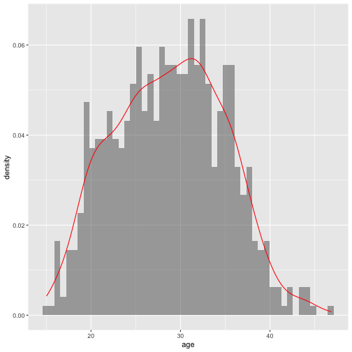

Simulated ages at motherhood, USA, 2021

```r
require (ggplot2)
d <- data.frame(age=ageFbirth)
p <- ggplot (data=d,aes(age))
p <- p + geom_histogram(aes(age,after_stat(density)),alpha=0.5,position="identity",bins=50)
p <- p + geom_density(alpha=0.2,col="red")
p
```

# Generate a virtual population

## With period data

The simulation uses mortality and fertility rates stored in the object rates. Suppose the virtual population consists of five overlapping generations. The code is:

```r
ncohort <- 1000
dLH <- GetGenerations (rates,ncohort=ncohort,ngen=5)
```

The object \(dLH\) includes data on all individuals in the virtual population, including children (generation 2), grandchildren (generation 3), great-grandchildren (generation 4) and great-great-grandchildren (generation 5). The structure of the object \(dLH\) is described in Appendix A. Note that the mothers and fathers of individuals in generation 1, which is the initial population, are unknown because they are not part of the virtual population. For members of the last (fifth) generation, the number of children is known? The IDs of the children (generation 6), their birth order and their dates of birth and death are also simulated, but information on their fertility career is missing.

The object \(dLH\) represents the main result of the VirtualPop package. One version of a \(dLH\) object is included in the VirtualPop package for easy reference. It is the virtual population generated from the mortality and fertility rates of the United States for 2021 and an initial cohort of 1000. The virtual population consists of 3937 individuals, including the children of members of the fifth generation. To load the data, use

```r
utils::data(dLH,package="VirtualPop")
```

It is good practice to save \(dLH\) as an R data file in a designated folder:

```r
path <- paste0("Folder to save the virtual population (dLH).",
             "To be defined by the user.")
ngen <- max(dLH$gen)-1
save (dLH,file=paste0(path,"dLH_",countrycode,"_",refyear,"_",ngen,"_",".RData"))
```

If path=NULL, the data are saved in the current working directory. To retrieve the data, use

```r
load(file=paste0(path,"dLH_",countrycode,"_",refyear,"_",ngen,"_",".RData"))
```

The name of the retrieved object is \(dLH\).

## With cohort data

The following code generates the virtual population with cohort data (USA, 1964 cohort):

```r
dLHc <- VirtualPop::GetGenerations (rates=ratesC,ncohort=1000,ngen=5)
```

```r
refyear <- attr(dLHc,"refyear")
cohort <- attr(dLHc,"cohort")
save (dLHc,file=paste0(path,"dLHc_",countrycode=countrycode,"_",
                       cohort,"_",refyear,".rda"))
```

The object dLHc has four attributes: country (USA), type of data (cohort), birth cohort (1964) and reference year (2021).

# Appendix A. The life histories data (dLH) object{-}

The dataframe dLH contains the life histories of all individuals in the initial birth cohort and their descendants. The dataframe has one record for each individual who was ever alive during the simulation. Individual attributes and event dates are stored in the columns. The dataframe dLH has the following columns:

- Identification number (\(ID\))
- Generation to which the individual belongs (\(gen\))
- Initial cohort (\(Cohort\))
- Sex (\(sex\))
- Decimal date of birth (\(bdated\)). A decimal date is a decimal representation of a date. It gives the calendar year and the fraction of the year. See vignette “Sampling Piecewise-Exponential Waiting Time Distributions”.
- Decimal date of death (\(ddated\))
- Age at death (\(x\_D\))
- ID of the partner (\(IDpartner\)). Since the number of males and females may not be exactly equal in the virtual population, some individuals remain without a partner.
- ID of the mother (\(IDmother\)). The ID is given when the mother of the individual is a member of the virtual population.
- ID of the father (\(IDfather\)). The ID of the father is the ID of the partner of the mother.
- Birth order or line number of the child (\(jch\)). This variable is given when the mother of the individual is a member of the virtual population.
- Number of children ever born to the individual with identification number ID (\(nch\)). The number of children is missing for males. Their children are the children of their partner.

Decimal dates may be converted into calendar dates. CRAN has several packages with functions to perform operations on dates. The package lubridate is one of them. It is part of the tidyverse collection of R packages. The date_decimal() function of the lubridate package converts a decimal date into a calendar date. R’s format function is used to obtain a calendar date in the desired format. The following code converts the decimal date 2020.409 into calendar date:

```r
date <- format(lubridate::date_decimal(2020.409), "%d %B %Y")
```

The calendar date is 29 May 2020. For a discussion of dates in demographic research, see @willekens2013chronological.

# Appendix B. Export the virtual population from R to STATA and SPSS{-}

The virtual population generated by \(GetGenerations()\) is stored in the \(dLH\) data frame. The data may be exported from R to a STATA or SPSS binary data format, using the package foreign, and saved at a desired location:

```r
path <- "" # or different path
foreign::write.dta(dLH, paste (path,"dLH.dta",sep=""))
```

with \(path\) the path of the directory in which the STATA file should be located. It the path is omitted, the file is saved in the working directory. The results of the simulation may also be saved as an SPSS file:

```r
foreign::write.foreign(dLH,
        paste (path,"dLH.txt",sep=""),
        paste (path,"dLH.sps",sep=""), package="SPSS")
```

The function creates a text file and an SPSS program to read it. The functions write.dta() and write.foreign() are functions of the package foreign. An alternative is to use the write_tda() and write_sav() functions of the haven package, which is part of the tidyverse collection of R packages.